# Cetacean Species Richness in California

ESM 244 - Assignment 3 Task 2

Minnie Ringland

Feb 25, 2021

### About the Data

AquaMaps is a tool that generates predictions for occurence of marine species. The model uses estimates of species preference for environmental conditions including depth, water temperature, salinity, primary productivity, and sea ice or coastal areas. These “environmental envelopes” are matched against local environmental conditions to determine the suitability of a given area in the ocean for a particular species.

We’ll generate predicted range maps for 35 cetacean species that can be found along the Southern California Bight, shown below.

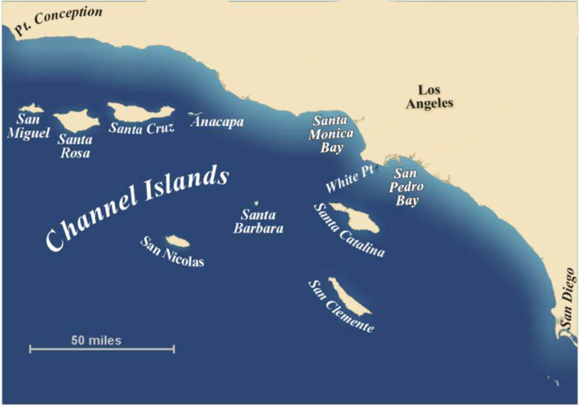

https://oceanservice.noaa.gov/facts/bight.html

### Probability Maps

For each species, we download a raster showing the probability of occurrence in each cell.

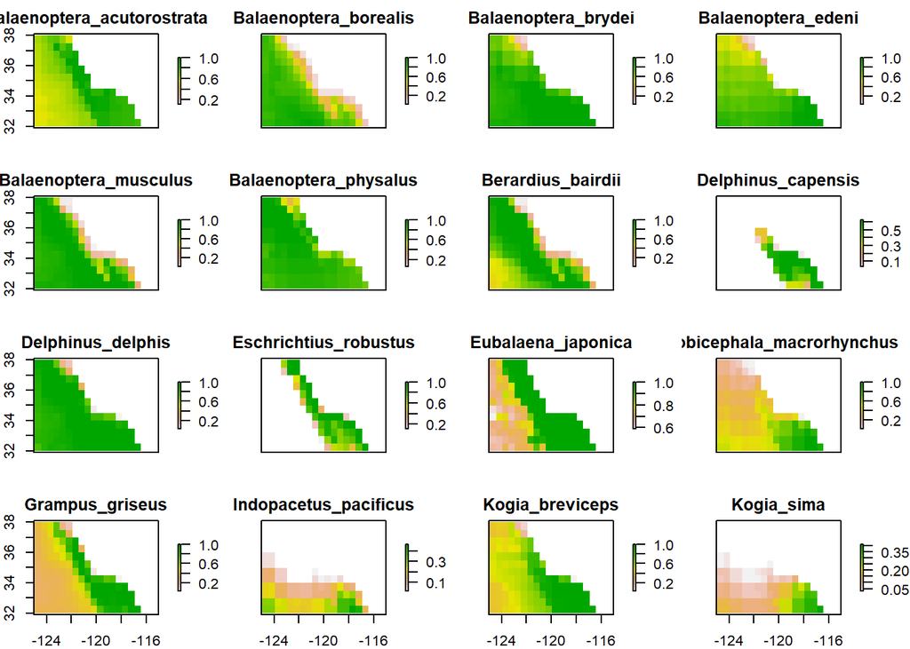

Figure 1. Probability of Occurence of 16 of 35 Cetacean Species

```r
# Create a list of files to use and rasterize as a stack

aquamap_files <- list.files(path = here("ca_cetaceans"), full.names = TRUE, pattern = "*.tif")

aq_stack <- raster::stack(aquamap_files)
smaller_aq <- raster::aggregate(aq_stack, fact = 2, fun = mean) # Use this smaller/faster version to build code

plot(aq_stack)
```

The gradient from green (high probability) to peach (low probability) gives a sense of the species’ spatial extent - areas where the species is very likely to be found and areas where the species may be found or occasionally is found but not often. We can see that the spatial distribution varies for each species.

For the purpose of determining overall species richness, we need a binary present/not present value for each species. We will therefore set a probability threshold of 0.7, above which we will consider the species present, and below which we will consider the species not present.

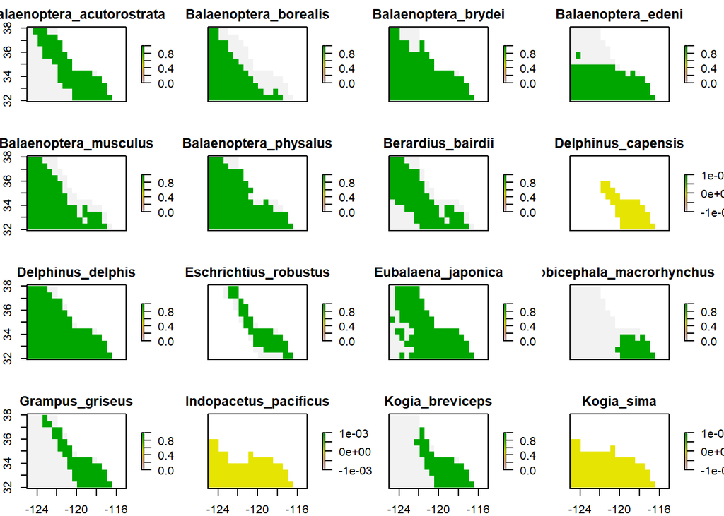

Figure 2. Binary Probability of Occurrence with Threshold of 0.7

```r
is_present <- function(x, thresh = 0.7) {
  y <- ifelse(x >= thresh, 1, 0)
  return(y)
}

#testvec <- c("1", "0.5")
#is_present(testvec)

presence <- calc(aq_stack, fun = is_present)
plot(presence)
```

We can now combine all layers to sum up total species richness, and provide the coastline as a background layer for context.

```r
# coastline downloaded from rnaturalearth

coast <- ne_coastline(scale = "medium", returnclass = "sf") # simple features so we can plot with geom_sf()

coast_df <- coast %>%
  as.data.frame()
#coast_df <- raster::rasterToPoints(coast) %>%
#  as.data.frame()
```

```r
# convert raster to dataframe for ggplot
richness <- calc(presence, fun = sum, na.rm = TRUE)

species_df <- raster::rasterToPoints(richness) %>%
  as.data.frame()
```

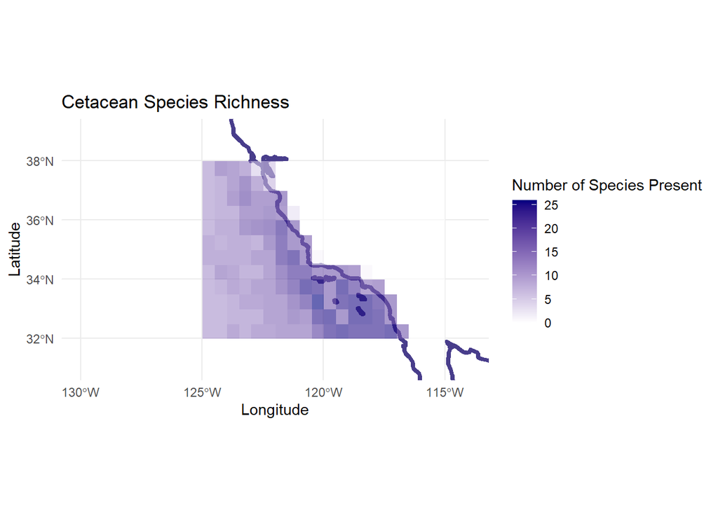

**Figure 3.** Cetacean Species Richness along the California Coast, using threshold probability > 0.7

```r
ggplot() +
 geom_sf(data = coast, size = 1.5, color = "darkslateblue") +
  geom_raster(data = species_df, aes(x = x, y = y, fill = layer), alpha = 0.6) +
   coord_sf(xlim = c(-130, -114), ylim = c(31, 39)) +
  scale_fill_gradient(low = 'white', high = 'navyblue') +
  labs(x = "Longitude", y = "Latitude", title = "Cetacean Species Richness", fill = "Number of Species Present") +
  theme_minimal() #+
```

```r
  #theme(panel.background = element_rect(fill = 'slateblue4'))
```

**Data Source:**

Kaschner, K., K. Kesner-Reyes, C. Garilao, J. Segschneider, J. Rius-Barile, T. Rees, and R. Froese. 2019. AquaMaps: Predicted range maps for aquatic species. World wide web electronic publication, [www.aquamaps.org], Version 10/2019.